# Analyzing Indicators of Heavy Traffic

This project is about analyzing [I-94 Interstate highway](https://en.wikipedia.org/wiki/Interstate_94) data and better understanding strong indicators of traffic for this highway such as weather and time of day.

This dataset was made available by John Hogue, and is found at [UCI Machine Learning Repository].(https://archive.ics.uci.edu/ml/datasets/Metro+Interstate+Traffic+Volume). This dataset contains westbound traffic data from Saint Paul to Minneapolis.

```python
import pandas as pd
import matplotlib.pyplot as plt
import seaborn as sns
import datetime as dt
```

```python
traffic = pd.read_csv('Metro_Interstate_Traffic_Volume.csv')
print(traffic)
print(traffic.info())
```

```
      holiday    temp  rain_1h  snow_1h  clouds_all  weather_main  \
0        None  288.28      0.0      0.0          40        Clouds
1        None  289.36      0.0      0.0          75        Clouds
2        None  289.58      0.0      0.0          90        Clouds
3        None  290.13      0.0      0.0          90        Clouds
4        None  291.14      0.0      0.0          75        Clouds
...       ...     ...      ...      ...         ...           ...
48199    None  283.45      0.0      0.0          75        Clouds
48200    None  282.76      0.0      0.0          90        Clouds
48201    None  282.73      0.0      0.0          90  Thunderstorm
48202    None  282.09      0.0      0.0          90        Clouds
48203    None  282.12      0.0      0.0          90        Clouds

          weather_description            date_time  traffic_volume
0            scattered clouds  2012-10-02 09:00:00            5545
1               broken clouds  2012-10-02 10:00:00            4516
2             overcast clouds  2012-10-02 11:00:00            4767
3             overcast clouds  2012-10-02 12:00:00            5026
4               broken clouds  2012-10-02 13:00:00            4918
...                       ...                  ...             ...
48199           broken clouds  2018-09-30 19:00:00            3543
48200         overcast clouds  2018-09-30 20:00:00            2781
48201  proximity thunderstorm  2018-09-30 21:00:00            2159
48202         overcast clouds  2018-09-30 22:00:00            1450
48203         overcast clouds  2018-09-30 23:00:00             954

[48204 rows x 9 columns]
<class 'pandas.core.frame.DataFrame'>
RangeIndex: 48204 entries, 0 to 48203
Data columns (total 9 columns):
 #   Column               Non-Null Count  Dtype
---  ------               --------------  -----
 0   holiday              48204 non-null  object
 1   temp                 48204 non-null  float64
 2   rain_1h              48204 non-null  float64
 3   snow_1h              48204 non-null  float64
 4   clouds_all           48204 non-null  int64
 5   weather_main         48204 non-null  object
 6   weather_description  48204 non-null  object
 7   date_time            48204 non-null  object
 8   traffic_volume       48204 non-null  int64
dtypes: float64(3), int64(2), object(4)
memory usage: 3.3+ MB
None
```

First, we will start by quickly exploring the data by creating a histogram.

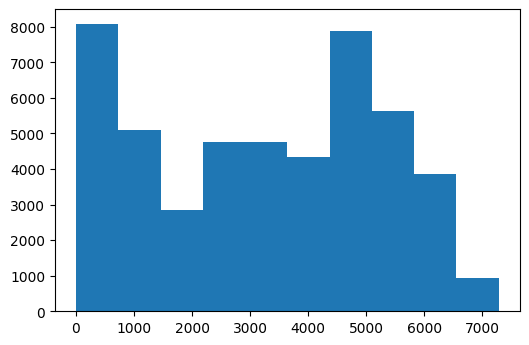

```
count    48204.000000
mean      3259.818355
std       1986.860670
min          0.000000
25%       1193.000000
50%       3380.000000
75%       4933.000000
max       7280.000000
Name: traffic_volume, dtype: float64
```

```python
%matplotlib inline

plt.hist(traffic['traffic_volume'])
plt.plot()
plt.show()

traffic['traffic_volume'].describe()
```

From analyzing the histogram, we can see that the graph is bi-modal.  
There is a high frequency of moments with few cars on the road (<1k) and a high frequency of many cars on the road (~5k). The high frequency of moments with few cars on the road could represent the late night/early morning where many are asleep. The high frequency of 5k+ cars on the road could represent rush hour where many people are going to or leaving work.  
In order to further analyze this, we will split our dataset into daytime driving (7 am to 7pm) and nighttime driving (7pm to 7am).

```python
traffic['date_time'] = pd.to_datetime(traffic['date_time'])
```

```python
traffic['daytime'] = traffic['date_time'].dt.hour.between(7,19)
```

We will graph traffic volume, splitting the daytime data and the nighttime data

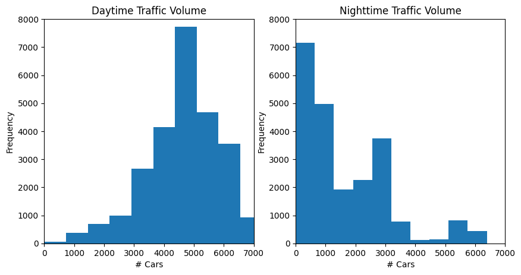

```python
plt.figure(figsize=[10,5])

daytime_traffic_volume = traffic[traffic['daytime'] == True]['traffic_volume']
nighttime_traffic_volume = traffic[traffic['daytime'] == False]['traffic_volume']

plt.subplot(1,2,1)
plt.hist(daytime_traffic_volume)
plt.title('Daytime Traffic Volume')
plt.xlabel('# Cars')
plt.ylabel('Frequency')
plt.xlim([0,7000])
plt.ylim([0,8000])
plt.subplot(1,2,2)
plt.hist(nighttime_traffic_volume)
plt.title('Nighttime Traffic Volume')
plt.xlabel('# Cars')
plt.ylabel('Frequency')
plt.xlim([0,7000])
plt.ylim([0,8000])
plt.show()
```

```python
print(daytime_traffic_volume.describe(),
nighttime_traffic_volume.describe())
```

```
count    25838.000000
mean      4649.292360
std       1202.321987
min          0.000000
25%       4021.000000
50%       4736.000000
75%       5458.000000
max       7280.000000
Name: traffic_volume, dtype: float64 count    22366.000000
mean      1654.648484
std       1425.175292
min          0.000000
25%        486.000000
50%       1056.500000
75%       2630.750000
max       6386.000000
Name: traffic_volume, dtype: float64
```

From looking at the histograms above and the traffic volume statistics, we can see that daytime traffic volume is slightly left skew and nighttime traffic volume is right skew.  
What this means is that most of the instances of high traffic count happen during the day and most of the instances of low traffic count happen during the night.  
For us to focus on instances of high traffic, it makes sense to exclude nighttime data in our analysis.

```python
traffic = traffic[traffic['daytime'] == True]
```

Next, we will look at how traffic differs month to month.

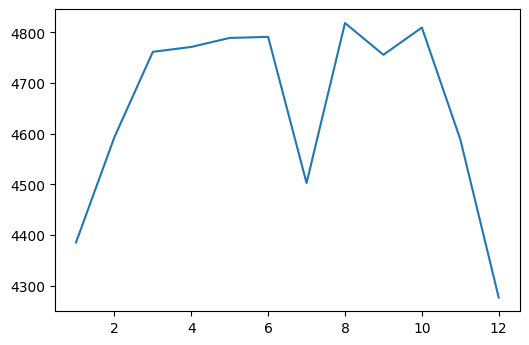

```python
traffic['month'] = traffic['date_time'].dt.month
monthly_traffic = traffic.groupby('month').mean()['traffic_volume']
plt.plot(monthly_traffic)
```

From the graph above, we can see that traffic throughout the year stays approximately uniform except for a dip in July and during late Autumn/early Winter (Holiday season). This makes sense as the holiday season is a common time to see family and people are more likely to be out of the area or driving in a different direction to see family from their usual route on I-94.

Now, we will look at how traffic differs depending on the day of week.

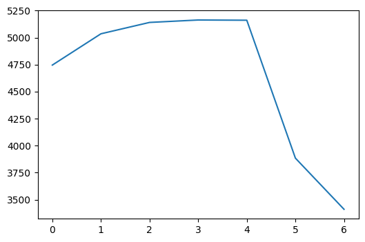

```python
traffic['day'] = traffic['date_time'].dt.dayofweek #0 is Monday, 6 is Sunday
weekday_traffic = traffic.groupby('day').mean()['traffic_volume']
plt.plot(weekday_traffic)
```

From plotting traffic by day of week, we can see that there is a slight increase in average traffic from Monday (day 0) to Friday, but a steep drop off after Friday. This makes sense because Monday through Friday, people are predictably traveling to and from work.  
Let's split our data between weekdays and weekends and see if traffic volume trends differ between theses 2 groups.

```python
traffic['hour'] = traffic['date_time'].dt.hour
workdays = traffic.copy()[traffic['day'] <= 4] #0 is Monday, 6 is Sunday
weekends = traffic.copy()[traffic['day'] > 4]
workdays = workdays.groupby('hour').mean()['traffic_volume']
weekends = weekends.groupby('hour').mean()['traffic_volume']
```

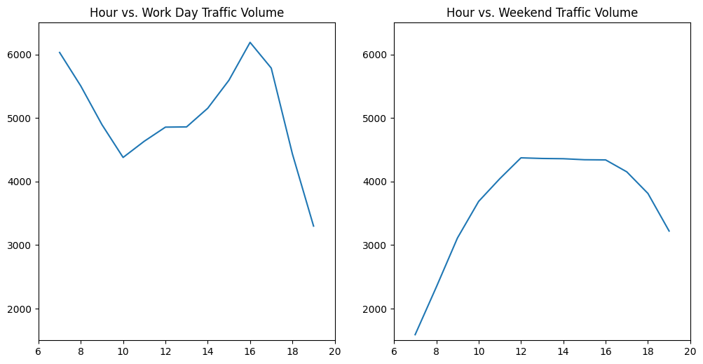

```python
plt.figure(figsize=[12,6])
plt.subplot(1,2,1)
plt.plot(workdays)
plt.title('Hour vs. Work Day Traffic Volume')
plt.xlim([6,20])
plt.ylim([1500,6500])
plt.subplot(1,2,2)
plt.plot(weekends)
plt.title('Hour vs. Weekend Traffic Volume')
plt.xlim([6,20])
plt.ylim([1500,6500])

plt.show()
```

Overall, business days have higher traffic than weekends, but the hours of peak traffic for each group is different. Business days see peak traffic (relative to other business day hours) at 7am and 4-5pm (common rush hours) while during the weekend, we see a smoother trend with peak hours (relative to other weekend hours) from noon to 4pm.

To summarize, we see the highest traffic during work days around the common rush hours of 7am and 4-5pm. Traffic is relatively low at night and on the weekends.

So far, we've been analyzing time indicators in our data, but have not looked at weather indicators yet. Heavy traffic could be a result of unfavorable weather like heavy rain or snow. Let's see if there's any correlation with traffic volume and weather conditions.

```python
traffic.corr()['traffic_volume']
traffic.copy()[traffic['day'] <= 4].corr()['traffic_volume']
```

```
temp              0.114327
rain_1h           0.003297
snow_1h          -0.002361
clouds_all       -0.071516
traffic_volume    1.000000
daytime                NaN
month            -0.021472
day               0.137659
hour             -0.221247
Name: traffic_volume, dtype: float64
```

There doesn't seem to be a strong correlation between traffic volume and any of our weather columns. The strongest correlation only has an r score of 0.11.

```python
by_weather_main = traffic.groupby('weather_main').mean()['traffic_volume']
by_weather_description = traffic.groupby('weather_description').mean()['traffic_volume']
```

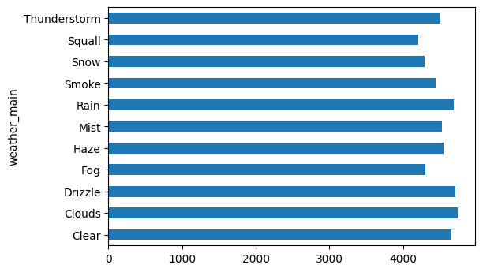

```python
by_weather_main.plot.barh()
```

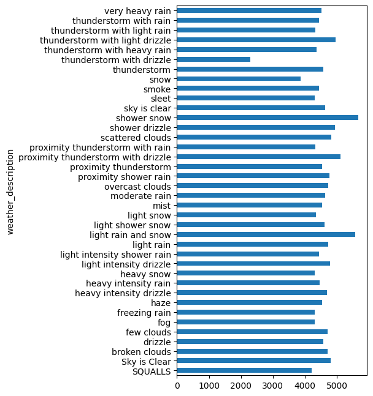

```python
plt.figure(figsize=[4,8])
by_weather_description.plot.barh()
```

From analyzing the weather descriptions during heavy traffic, there seem to be heavy traffic during shower snow and light rain and snow with traffic volumes of over 5000 cars on average with these conditions.